# liuhongyang-test

##### Name: LIU,HONGYANG

##### Matric Number: 17201091/1

**Target crawling website:** https://www.macrotrends.net/2516/wti-crude-oil-prices-10-year-daily-chart

**1.You are required to write code that will crawl the WWW (your familiar domain) of a particular website and collect data from social media or from report or news and so on and to produce dataset.**

```python
#crawl oil Price data
import requests
import requests.cookies
import json
import time
import pandas as pd
from bs4 import BeautifulSoup

url='https://www.macrotrends.net/2516/wti-crude-oil-prices-10-year-daily-chart'

headers={
    'User-Agent':'Mozilla/5.0 (Macintosh; Intel Mac OS X 10_15_3) AppleWebKit/537.36 (KHTML, like Gecko) Chrome/80.0.3987.122 Safari/537.36'
}

res = requests.get(url,headers=headers)


try:

    df = pd.read_html(res.text)
    pan = pd.DataFrame(df[0])
    d={'Year':pan.iloc[:,0],'AverageClosing Price':pan.iloc[:,1],'Year Open':pan.iloc[:,2],'Year High':pan.iloc[:,3],'Year Low':pan.iloc[:,4],'Year Close':pan.iloc[:,5],'Annual% Change':pan.iloc[:,6]}
    df = pd.DataFrame(data=d)
    df.to_csv('oilCrawl.csv')
except:

    print("The url doesn't work!")
df.head()
```

|  | Year | AverageClosing Price | Year Open | Year High | Year Low | Year Close | Annual% Change |
| --- | --- | --- | --- | --- | --- | --- | --- |
| 0 | 2020 | $37.49 | $61.17 | $63.27 | $11.26 | $33.49 | -45.22% |
| 1 | 2019 | $56.99 | $46.31 | $66.24 | $46.31 | $61.14 | 35.42% |
| 2 | 2018 | $65.23 | $60.37 | $77.41 | $44.48 | $45.15 | -25.32% |
| 3 | 2017 | $50.80 | $52.36 | $60.46 | $42.48 | $60.46 | 12.48% |
| 4 | 2016 | $43.29 | $36.81 | $54.01 | $26.19 | $53.75 | 44.76% |

**2. After that you are required to write code to modify and/or select your the attributes to perform the following tasks: Data Cleaning Data Integration Data Transformation Data Reduction Hint : Make sure that use graph to help you select appropriate attributes to perform the above tasks.**

#### 2.1 Data Cleaning

```python
#check missing data
df.isnull().sum().any()
```

```
False
```

```python
#check duplicated data
df.loc[df.duplicated(),:]
```

|  | Year | AverageClosing Price | Year Open | Year High | Year Low | Year Close | Annual% Change |
| --- | --- | --- | --- | --- | --- | --- | --- |

```python
#check inconsistent data;
#we can find the type of attributes are inconsistent
df.dtypes
```

```
Year                     int64
AverageClosing Price    object
Year Open               object
Year High               object
Year Low                object
Year Close              object
Annual% Change          object
dtype: object
```

Consequently, we need use data cleaning to change the data types of the attributes and make the data types become numeric.

#### 2.2 Data Integration

- we will download another source data from this website: https://datahub.io/core/gdp-us
- Integrate the two kind of sources into one

```python
#download and read another data source
AmericaGdp=pd.read_csv('year_csv.csv')

#check the first five rows of data
AmericaGdp.head()
```

|  | date | level-current | level-chained | change-current | change-chained |
| --- | --- | --- | --- | --- | --- |
| 0 | 1930 | 92.2 | 966.7 | -16.0 | -6.4 |
| 1 | 1931 | 77.4 | 904.8 | -23.1 | -12.9 |
| 2 | 1932 | 59.5 | 788.2 | -4.0 | -1.3 |
| 3 | 1933 | 57.2 | 778.3 | 16.9 | 10.8 |
| 4 | 1934 | 66.8 | 862.2 | 11.1 | 8.9 |

```python
#1.rename "data" attributes to "Year"
#2.we will integrate attributes in AmericaGdp datasets with the attributes oilPrice datasets in Question 4;

AmericaGdp=AmericaGdp.rename(columns={'date':'Year'})
AmericaGdp.head()
```

|  | Year | level-current | level-chained | change-current | change-chained |
| --- | --- | --- | --- | --- | --- |
| 0 | 1930 | 92.2 | 966.7 | -16.0 | -6.4 |
| 1 | 1931 | 77.4 | 904.8 | -23.1 | -12.9 |
| 2 | 1932 | 59.5 | 788.2 | -4.0 | -1.3 |
| 3 | 1933 | 57.2 | 778.3 | 16.9 | 10.8 |
| 4 | 1934 | 66.8 | 862.2 | 11.1 | 8.9 |

After intergration in Question 4: the data sets should look like this:

[figure not shown]

#### 2.3 Transformation

```python
# check the oilPrice datasets
df.describe()
```

|  | Year |
| --- | --- |
| count | 34.000000 |
| mean | 2003.500000 |
| std | 9.958246 |
| min | 1987.000000 |
| 25% | 1995.250000 |
| 50% | 2003.500000 |
| 75% | 2011.750000 |
| max | 2020.000000 |

```python
# check the AmericaGdp datasets
AmericaGdp.describe()
```

|  | Year | level-current | level-chained | change-current | change-chained |
| --- | --- | --- | --- | --- | --- |
| count | 86.000000 | 86.000000 | 86.000000 | 86.000000 | 86.000000 |
| mean | 1972.500000 | 4354.769767 | 6476.491860 | 6.587209 | 3.480233 |
| std | 24.969982 | 5357.258048 | 4790.501749 | 6.655414 | 4.795091 |
| min | 1930.000000 | 57.200000 | 778.300000 | -23.100000 | -12.900000 |
| 25% | 1951.250000 | 352.400000 | 2384.025000 | 4.125000 | 1.725000 |
| 50% | 1972.500000 | 1355.450000 | 5259.850000 | 6.300000 | 3.400000 |
| 75% | 1993.750000 | 7201.275000 | 9809.300000 | 9.550000 | 5.175000 |
| max | 2015.000000 | 18120.700000 | 16471.500000 | 28.300000 | 18.900000 |

**Run the code`AmericaGdp.describe()`, check the standard deviation, we can find the `level-current` `level-chained` columns have very high standard deviation.**

**we need scale the two attributes in Question 5**

[figure not shown]

#### 2.4 Data Reduction

```python
# check the AmericaGdp columns
AmericaGdp.columns
```

```
Index(['Year', 'level-current', 'level-chained', 'change-current',
       'change-chained'],
      dtype='object')
```

```python
#check the oil price columns
df.columns
```

```
Index(['Year', 'AverageClosing Price', 'Year Open', 'Year High', 'Year Low',
       'Year Close', 'Annual% Change'],
      dtype='object')
```

we will delete some unrelated attributes to make datasets that have only two components: **features** and **targets**

```python
#fautures:
features=['level-current','level-chained','change-current','change-chained']

#targets:
targets=['Year Close']
```

Finally, we will use PCA to do **reduce features attributes and dimensionality** in Question 6

**3.You are required to write data cleaning code using the appropriate attribute (Question 2). In order to achieve the task, you are going to cover the following steps: Importing required libraries Loading Data Before data cleaning, plot your result (attribute) Data cleaning After data cleaning, plot your result (attribute)**

```python
# import libraries
import pandas as pd
```

before data cleaning

```python
df.head()
```

|  | Year | AverageClosing Price | Year Open | Year High | Year Low | Year Close | Annual% Change |
| --- | --- | --- | --- | --- | --- | --- | --- |
| 0 | 2020 | $37.49 | $61.17 | $63.27 | $11.26 | $33.49 | -45.22% |
| 1 | 2019 | $56.99 | $46.31 | $66.24 | $46.31 | $61.14 | 35.42% |
| 2 | 2018 | $65.23 | $60.37 | $77.41 | $44.48 | $45.15 | -25.32% |
| 3 | 2017 | $50.80 | $52.36 | $60.46 | $42.48 | $60.46 | 12.48% |
| 4 | 2016 | $43.29 | $36.81 | $54.01 | $26.19 | $53.75 | 44.76% |

data cleaning

```python
# In quesion2, we note that the data is inconsistent because we need remove symbol'$' and '%'
df.loc[:,['AverageClosing Price','Annual% Change']].head()
```

|  | AverageClosing Price | Annual% Change |
| --- | --- | --- |
| 0 | $37.49 | -45.22% |
| 1 | $56.99 | 35.42% |
| 2 | $65.23 | -25.32% |
| 3 | $50.80 | 12.48% |
| 4 | $43.29 | 44.76% |

```python
#Removing the symbol '%' and '$'
df['Annual% Change'] = list(map(lambda x: x[:-1], df['Annual% Change'].values))
df['AverageClosing Price'] = list(map(lambda x: x[1:], df['AverageClosing Price'].values))
df['Year Open'] = list(map(lambda x: x[1:], df['Year Open'].values))
df['Year High'] = list(map(lambda x: x[1:], df['Year High'].values))
df['Year Low'] = list(map(lambda x: x[1:], df['Year Low'].values))
df['Year Close'] = list(map(lambda x: x[1:], df['Year Close'].values))


df.head()
```

|  | Year | AverageClosing Price | Year Open | Year High | Year Low | Year Close | Annual% Change |
| --- | --- | --- | --- | --- | --- | --- | --- |
| 0 | 2020 | 37.49 | 61.17 | 63.27 | 11.26 | 33.49 | -45.22 |
| 1 | 2019 | 56.99 | 46.31 | 66.24 | 46.31 | 61.14 | 35.42 |
| 2 | 2018 | 65.23 | 60.37 | 77.41 | 44.48 | 45.15 | -25.32 |
| 3 | 2017 | 50.80 | 52.36 | 60.46 | 42.48 | 60.46 | 12.48 |
| 4 | 2016 | 43.29 | 36.81 | 54.01 | 26.19 | 53.75 | 44.76 |

```python
# then, we need solve data inconsistent problem
df.dtypes
```

```
Year                     int64
AverageClosing Price    object
Year Open               object
Year High               object
Year Low                object
Year Close              object
Annual% Change          object
dtype: object
```

```python
#after the '%' and '$' symbol has been removed
# We note that column values for columns have data types of string
# so we need to convert these to numeric data as follows:
df['Annual% Change'] = [float(x) for x in df['Annual% Change'].values]
df['AverageClosing Price'] = [float(x) for x in df['AverageClosing Price'].values]
df['Year Open'] = [float(x) for x in df['Year Open'].values]
df['Year High'] = [float(x) for x in df['Year High'].values]
df['Year Low'] = [float(x) for x in df['Year Low'].values]
df['Year Close'] = [float(x) for x in df['Year Close'].values]

df.head()
```

|  | Year | AverageClosing Price | Year Open | Year High | Year Low | Year Close | Annual% Change |
| --- | --- | --- | --- | --- | --- | --- | --- |
| 0 | 2020 | 37.49 | 61.17 | 63.27 | 11.26 | 33.49 | -45.22 |
| 1 | 2019 | 56.99 | 46.31 | 66.24 | 46.31 | 61.14 | 35.42 |
| 2 | 2018 | 65.23 | 60.37 | 77.41 | 44.48 | 45.15 | -25.32 |
| 3 | 2017 | 50.80 | 52.36 | 60.46 | 42.48 | 60.46 | 12.48 |
| 4 | 2016 | 43.29 | 36.81 | 54.01 | 26.19 | 53.75 | 44.76 |

after data cleaning

```python
#check the data
df.head()
```

|  | Year | AverageClosing Price | Year Open | Year High | Year Low | Year Close | Annual% Change |
| --- | --- | --- | --- | --- | --- | --- | --- |
| 0 | 2020 | 37.49 | 61.17 | 63.27 | 11.26 | 33.49 | -45.22 |
| 1 | 2019 | 56.99 | 46.31 | 66.24 | 46.31 | 61.14 | 35.42 |
| 2 | 2018 | 65.23 | 60.37 | 77.41 | 44.48 | 45.15 | -25.32 |
| 3 | 2017 | 50.80 | 52.36 | 60.46 | 42.48 | 60.46 | 12.48 |
| 4 | 2016 | 43.29 | 36.81 | 54.01 | 26.19 | 53.75 | 44.76 |

```python
#check the data type
df.dtypes
```

```
Year                      int64
AverageClosing Price    float64
Year Open               float64
Year High               float64
Year Low                float64
Year Close              float64
Annual% Change          float64
dtype: object
```

**4. You are required to write data integration code using the appropriate attribute (Question 2). In order to achieve the task, you are going to cover the following steps: Importing required libraries Loading Data Before data cleaning, plot your result (attribute) Data cleaning After data cleaning, plot your result (attribute)**

```python
# import libraries
import pandas as pd
```

before integraion

```python
#oilPrice datasets
df.head()
```

|  | Year | AverageClosing Price | Year Open | Year High | Year Low | Year Close | Annual% Change |
| --- | --- | --- | --- | --- | --- | --- | --- |
| 0 | 2020 | 37.49 | 61.17 | 63.27 | 11.26 | 33.49 | -45.22 |
| 1 | 2019 | 56.99 | 46.31 | 66.24 | 46.31 | 61.14 | 35.42 |
| 2 | 2018 | 65.23 | 60.37 | 77.41 | 44.48 | 45.15 | -25.32 |
| 3 | 2017 | 50.80 | 52.36 | 60.46 | 42.48 | 60.46 | 12.48 |
| 4 | 2016 | 43.29 | 36.81 | 54.01 | 26.19 | 53.75 | 44.76 |

```python
#American gdp datasets
AmericaGdp.head()
```

|  | Year | level-current | level-chained | change-current | change-chained |
| --- | --- | --- | --- | --- | --- |
| 0 | 1930 | 92.2 | 966.7 | -16.0 | -6.4 |
| 1 | 1931 | 77.4 | 904.8 | -23.1 | -12.9 |
| 2 | 1932 | 59.5 | 788.2 | -4.0 | -1.3 |
| 3 | 1933 | 57.2 | 778.3 | 16.9 | 10.8 |
| 4 | 1934 | 66.8 | 862.2 | 11.1 | 8.9 |

integration

```python
# According to quesiont2.2,we will merge df sets and American GDP sets
#merge two data sources: oldPrice and American GDP, using Year value
integration=pd.merge(df,AmericaGdp,on='Year')
```

after integration

```python
integration.head()
```

|  | Year | AverageClosing Price | Year Open | Year High | Year Low | Year Close | Annual% Change | level-current | level-chained | change-current | change-chained |
| --- | --- | --- | --- | --- | --- | --- | --- | --- | --- | --- | --- |
| 0 | 2015 | 48.66 | 52.72 | 61.36 | 34.55 | 37.13 | -30.53 | 18120.7 | 16471.5 | 2.8 | 1.5 |
| 1 | 2014 | 93.17 | 95.14 | 107.95 | 53.45 | 53.45 | -45.55 | 17427.6 | 16013.3 | 4.0 | 2.9 |
| 2 | 2013 | 97.98 | 93.14 | 110.62 | 86.65 | 98.17 | 6.90 | 16691.5 | 15612.2 | 4.4 | 2.6 |
| 3 | 2012 | 94.05 | 102.96 | 109.39 | 77.72 | 91.83 | -7.08 | 16155.3 | 15354.6 | 3.3 | 1.7 |
| 4 | 2011 | 94.88 | 91.59 | 113.39 | 75.40 | 98.83 | 8.15 | 15517.9 | 15020.6 | 4.1 | 2.2 |

**5. You are required to write data transformation code using the appropriate attribute (Question 2). In order to achieve the task, you are going to cover the following steps: Importing required libraries Loading Data Before data transformation, plot your result (attributes) Data transformation After data transformation, plot your result (attributes) Hint : Normalization, Aggregation and Generalization**

```python
# import libraries
import pandas as pd
from sklearn import preprocessing
```

before transformation

```python
#check the value
integration.head()
```

|  | Year | AverageClosing Price | Year Open | Year High | Year Low | Year Close | Annual% Change | level-current | level-chained | change-current | change-chained |
| --- | --- | --- | --- | --- | --- | --- | --- | --- | --- | --- | --- |
| 0 | 2015 | 48.66 | 52.72 | 61.36 | 34.55 | 37.13 | -30.53 | 18120.7 | 16471.5 | 2.8 | 1.5 |
| 1 | 2014 | 93.17 | 95.14 | 107.95 | 53.45 | 53.45 | -45.55 | 17427.6 | 16013.3 | 4.0 | 2.9 |
| 2 | 2013 | 97.98 | 93.14 | 110.62 | 86.65 | 98.17 | 6.90 | 16691.5 | 15612.2 | 4.4 | 2.6 |
| 3 | 2012 | 94.05 | 102.96 | 109.39 | 77.72 | 91.83 | -7.08 | 16155.3 | 15354.6 | 3.3 | 1.7 |
| 4 | 2011 | 94.88 | 91.59 | 113.39 | 75.40 | 98.83 | 8.15 | 15517.9 | 15020.6 | 4.1 | 2.2 |

```python
#check the specific measures:
integration.describe()
```

|  | Year | AverageClosing Price | Year Open | Year High | Year Low | Year Close | Annual% Change | level-current | level-chained | change-current | change-chained |
| --- | --- | --- | --- | --- | --- | --- | --- | --- | --- | --- | --- |
| count | 29.000000 | 29.000000 | 29.000000 | 29.000000 | 29.000000 | 29.000000 | 29.000000 | 29.000000 | 29.000000 | 29.000000 | 29.000000 |
| mean | 2001.000000 | 43.863103 | 41.962414 | 54.703448 | 31.720690 | 42.143793 | 8.767241 | 10927.417241 | 12371.534483 | 4.765517 | 2.531034 |
| std | 8.514693 | 30.199817 | 30.192815 | 37.337284 | 22.193965 | 29.380178 | 37.793279 | 4090.517387 | 2635.239268 | 1.996117 | 1.651645 |
| min | 1987.000000 | 14.420000 | 12.420000 | 17.930000 | 10.820000 | 12.140000 | -53.520000 | 4870.200000 | 8132.600000 | -2.000000 | -2.800000 |
| 25% | 1994.000000 | 19.640000 | 19.030000 | 24.620000 | 16.860000 | 19.490000 | -25.300000 | 7308.800000 | 9905.400000 | 3.700000 | 1.800000 |
| 50% | 2001.000000 | 26.190000 | 26.530000 | 37.220000 | 18.020000 | 28.480000 | 4.170000 | 10621.800000 | 12682.200000 | 4.900000 | 2.700000 |
| 75% | 2008.000000 | 66.050000 | 60.770000 | 81.030000 | 42.160000 | 60.850000 | 30.400000 | 14477.600000 | 14783.800000 | 6.300000 | 3.800000 |
| max | 2015.000000 | 99.670000 | 102.960000 | 145.310000 | 86.650000 | 98.830000 | 112.190000 | 18120.700000 | 16471.500000 | 7.900000 | 4.700000 |

**we need scale the two attributes**

[figure not shown]

data transformation

```python
transformation = preprocessing.scale(integration.loc[:,['level-current','level-chained']])
transformation  = pd.DataFrame(transformation,columns=['level-current','level-chained'])


integration['level-current'] = transformation['level-current']
integration['level-chained'] = transformation['level-chained']
```

after transformation

```python
#check the value
integration.head()
```

|  | Year | AverageClosing Price | Year Open | Year High | Year Low | Year Close | Annual% Change | level-current | level-chained | change-current | change-chained |
| --- | --- | --- | --- | --- | --- | --- | --- | --- | --- | --- | --- |
| 0 | 2015 | 48.66 | 52.72 | 61.36 | 34.55 | 37.13 | -30.53 | 1.789653 | 1.583362 | 2.8 | 1.5 |
| 1 | 2014 | 93.17 | 95.14 | 107.95 | 53.45 | 53.45 | -45.55 | 1.617213 | 1.406410 | 4.0 | 2.9 |
| 2 | 2013 | 97.98 | 93.14 | 110.62 | 86.65 | 98.17 | 6.90 | 1.434075 | 1.251509 | 4.4 | 2.6 |
| 3 | 2012 | 94.05 | 102.96 | 109.39 | 77.72 | 91.83 | -7.08 | 1.300671 | 1.152027 | 3.3 | 1.7 |
| 4 | 2011 | 94.88 | 91.59 | 113.39 | 75.40 | 98.83 | 8.15 | 1.142089 | 1.023040 | 4.1 | 2.2 |

```python
#check the specific measures:
#we can find the attributes have been scaled
integration.describe()
```

|  | Year | AverageClosing Price | Year Open | Year High | Year Low | Year Close | Annual% Change | level-current | level-chained | change-current | change-chained |
| --- | --- | --- | --- | --- | --- | --- | --- | --- | --- | --- | --- |
| count | 29.000000 | 29.000000 | 29.000000 | 29.000000 | 29.000000 | 29.000000 | 29.000000 | 2.900000e+01 | 2.900000e+01 | 29.000000 | 29.000000 |
| mean | 2001.000000 | 43.863103 | 41.962414 | 54.703448 | 31.720690 | 42.143793 | 8.767241 | 1.148507e-16 | -1.914178e-16 | 4.765517 | 2.531034 |
| std | 8.514693 | 30.199817 | 30.192815 | 37.337284 | 22.193965 | 29.380178 | 37.793279 | 1.017700e+00 | 1.017700e+00 | 1.996117 | 1.651645 |
| min | 1987.000000 | 14.420000 | 12.420000 | 17.930000 | 10.820000 | 12.140000 | -53.520000 | -1.507006e+00 | -1.637030e+00 | -2.000000 | -2.800000 |
| 25% | 1994.000000 | 19.640000 | 19.030000 | 24.620000 | 16.860000 | 19.490000 | -25.300000 | -9.002941e-01 | -9.523941e-01 | 3.700000 | 1.800000 |
| 50% | 2001.000000 | 26.190000 | 26.530000 | 37.220000 | 18.020000 | 28.480000 | 4.170000 | -7.603606e-02 | 1.199756e-01 | 4.900000 | 2.700000 |
| 75% | 2008.000000 | 66.050000 | 60.770000 | 81.030000 | 42.160000 | 60.850000 | 30.400000 | 8.832679e-01 | 9.315905e-01 | 6.300000 | 3.800000 |
| max | 2015.000000 | 99.670000 | 102.960000 | 145.310000 | 86.650000 | 98.830000 | 112.190000 | 1.789653e+00 | 1.583362e+00 | 7.900000 | 4.700000 |

From the desceibe() method, we can find the two attributes **level-current** and **level-chained** have been scaled.

[figure not shown]

**6. You are required to write data reduction code using the appropriate attribute (Question 2). In order to achieve the task, you are going to cover the following steps: Importing required libraries Loading Data Before data reduction, plot your result (attributes) Data reduction After data reduction, plot your result (attributes)**

```python
# import libraries
import pandas as pd
from sklearn.preprocessing import StandardScaler
from sklearn.decomposition import PCA
```

before reduction

```python
integration.head()
```

|  | Year | AverageClosing Price | Year Open | Year High | Year Low | Year Close | Annual% Change | level-current | level-chained | change-current | change-chained |
| --- | --- | --- | --- | --- | --- | --- | --- | --- | --- | --- | --- |
| 0 | 2015 | 48.66 | 52.72 | 61.36 | 34.55 | 37.13 | -30.53 | 1.789653 | 1.583362 | 2.8 | 1.5 |
| 1 | 2014 | 93.17 | 95.14 | 107.95 | 53.45 | 53.45 | -45.55 | 1.617213 | 1.406410 | 4.0 | 2.9 |
| 2 | 2013 | 97.98 | 93.14 | 110.62 | 86.65 | 98.17 | 6.90 | 1.434075 | 1.251509 | 4.4 | 2.6 |
| 3 | 2012 | 94.05 | 102.96 | 109.39 | 77.72 | 91.83 | -7.08 | 1.300671 | 1.152027 | 3.3 | 1.7 |
| 4 | 2011 | 94.88 | 91.59 | 113.39 | 75.40 | 98.83 | 8.15 | 1.142089 | 1.023040 | 4.1 | 2.2 |

data reduction

```python
#fautures:
features=['level-current','level-chained','change-current','change-chained']

#targets:
targets=['Year Close']

# Separating out the features
x = integration.loc[:,features].values
# Separating out the target
y = integration.loc[:,targets].values

# Standardizing the features
x = StandardScaler().fit_transform(x)
```

```python
pca = PCA(n_components=2)
principalComponents = pca.fit_transform(x)
principalDf = pd.DataFrame(data = principalComponents
             , columns = ['principal component 1', 'principal component 2'])
```

```python
#the features have been change from four to two
finalDf = pd.concat([principalDf, df[targets]], axis = 1)
```

after data reduction

```python
finalDf.head()
```

|  | principal component 1 | principal component 2 | Year Close |
| --- | --- | --- | --- |
| 0 | 2.534063 | -0.820211 | 33.49 |
| 1 | 1.644059 | -1.426582 | 61.14 |
| 2 | 1.450175 | -1.239043 | 45.15 |
| 3 | 1.875149 | -0.558608 | 60.46 |
| 4 | 1.375971 | -0.776668 | 53.75 |

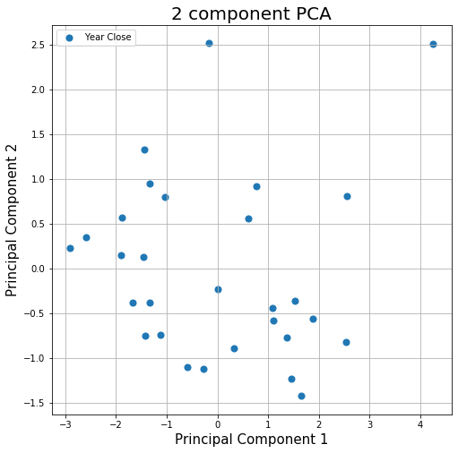

```python
import matplotlib.pyplot as plt

fig = plt.figure(figsize = (8,8))
ax = fig.add_subplot(1,1,1)
ax.set_xlabel('Principal Component 1', fontsize = 15)
ax.set_ylabel('Principal Component 2', fontsize = 15)
ax.set_title('2 component PCA', fontsize = 20)


ax.scatter(finalDf.loc[:, 'principal component 1']
               , finalDf.loc[:, 'principal component 2']
               , s = 50)
ax.legend(targets)
ax.grid()
```

the four attributes **features=['level-current','level-chained','change-current','change-chained']** have been reduced to two attributes.